# Relationship between CNH to USD Exchange Rate and S&P 500 Index

# 3. GARCH Modeling

Our first alternative is to fit GARCH(p,q) model, which is widely used for financial time series modeling. The GARCH(p,q) model can be expressed as
$$Y_t=\epsilon_t \sqrt{V_t}$$
where $V_t=\alpha_0+\sum_{j=1}^{p} \alpha_j Y_{t-j}^2+\sum_{k=1}^{q} \beta_k V_{n-k}$ and $\epsilon_t$ are white noise.

```
##
## Call:
## garch(x = ex_data$Rate, grad = "numerical", trace = FALSE)
##
## Model:
## GARCH(1,1)
##
## Residuals:
##    Min     1Q Median     3Q    Max
## 0.9526 0.9782 0.9792 0.9802 0.9941
##
## Coefficient(s):
##     Estimate  Std. Error  t value Pr(>|t|)
## a0 8.947e-02   7.173e+02    0.000    1.000
## a1 1.041e+00   3.006e+02    0.003    0.997
## b1 1.115e-10   2.887e+02    0.000    1.000
##
## Diagnostic Tests:
##  Jarque Bera Test
##
## data:  Residuals
## X-squared = 18097, df = 2, p-value < 2.2e-16
##
##
##  Box-Ljung test
##
## data:  Squared.Residuals
## X-squared = 8.5703, df = 1, p-value = 0.003417
```

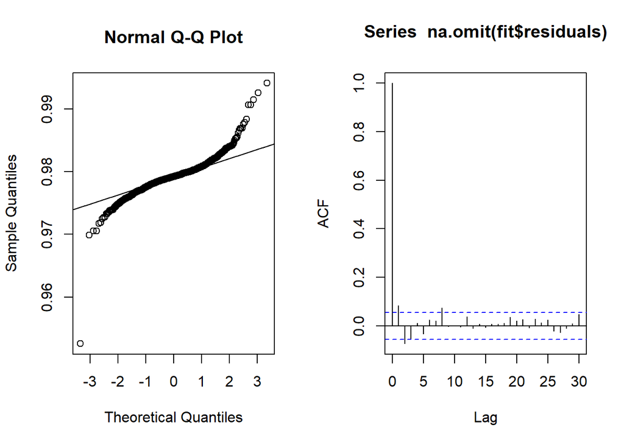

# 4. POMP Modeling

## 4.2 Parameters description and empirical estimation

There are two parameters in total for this model, they are:

1. drift parameter for constant trend: $\mu$;
2. volatility parameter for deviations: $\delta$;

After taking the difference of log of original time series, we get $log(N_t)-log(N_{t-1})$, which should follows a normal distribution with mean $\mu$ and standard deviation $\delta$. We use our historical data and get empirical sample mean and sample standard deviation as follow.

```
## [1] -2.321843e-05
```

```
## [1] 0.002357479
```

## 4.3 POMP Model Description

The initial value of N is drawn from a normal distribution with mean 6.5 and standard divation 0.3. The initial value of is drawn from a normal distribution with mean 1 and standard divation 1. The rmeasure is defined as Rate being drawn from a random draw from the normal distribution with mean 0 and variance, which is the state variable. Implementation details:

```r
ex_statenames <- c("N","e")
ex_paramnames <- c("mu","delta")
ex_dmeasure <- Csnippet("lik = dnorm(Rate,0,N,give_log);")
ex_rmeasure <- Csnippet("Rate = rnorm(0,N);")
ex_rprocess <- Csnippet(" e = rnorm(0,1);N = N*exp((mu-delta*delta/2)+delta*e);")
ex_initializer <-"N=rnorm(6.5,0.3);e=rnorm(1,1);"
stopifnot(packageVersion("pomp")>="0.75-1")
ex_fromEstimationScale <- "Tmu = exp(mu);Tdelta = expit(delta);"
ex_toEstimationScale <- "Tmu = log(mu);Tdelta = logit(delta);"
```

Please be noted that this file is executed under level 1, the level 3 output is stored in a seperate file Rplot.pdf. We first set up a pomp object likes following, and generate a bunch of simulated trajectories at some particular point in parameter space.

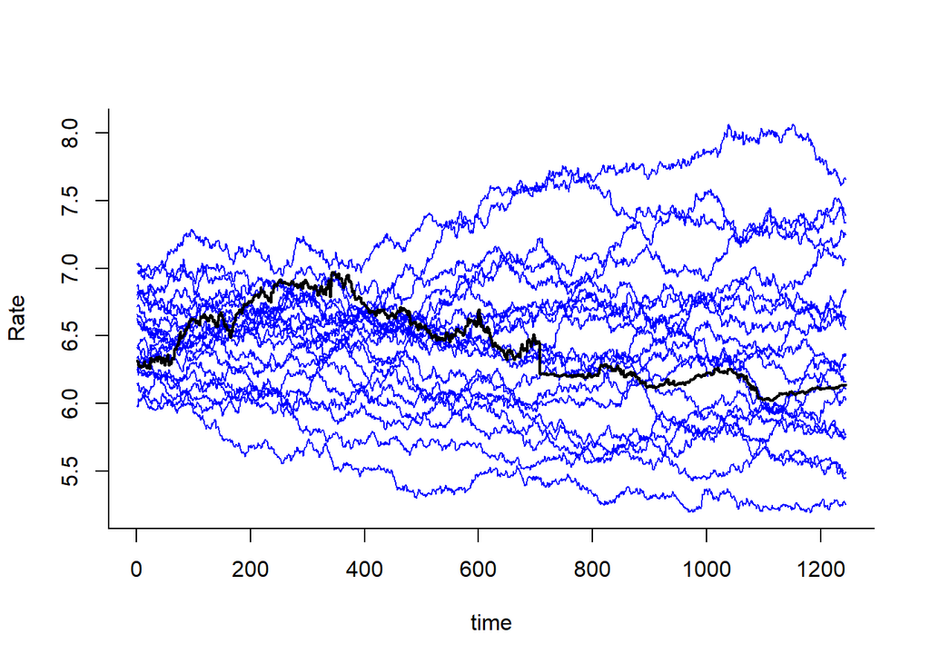

```r
ex <<- pomp(
  data=ex_data,
  times="Day",
  t0=0,
  rprocess=discrete.time.sim(step.fun=ex_rprocess,delta.t=1),
  rmeasure=ex_rmeasure,
  dmeasure=ex_dmeasure,
  obsnames ="Rate",
  statenames=ex_statenames,
  paramnames=ex_paramnames,
  initializer=Csnippet(ex_initializer))

simulate(ex,params=c(mu=mu0,delta=delta0),nsim=20,states=TRUE) -> x
matplot(time(ex),t(x["N",1:20,]),type='l',lty=1, xlab="time",ylab="Rate",bty='l',col='blue')
lines(time(ex),obs(ex,"Rate"),lwd=2,col='black')
```

## 4.4 Loglikehood Slice and Surface

The basic particle filter is implemented in the command pfilter in pomp. A theoretical property of the particle filter is that it gives us an unbiased Monte Carlo estimate of the likelihood.

This theoretical property, combined with Jensen’s inequality and the observation that is a concave function, ensures that the average of the log likelihoods from many particle filter replications will have negative bias as a Monte Carlo estimator of the log likelihood. By using logmeanexp to average the likelihood estimates on the natural scale not the logarithmic scale.

Here we evaluate the log likelihood of the data given the states, the model, and the parameters:

```r
pf <- pfilter(ex,Np=ex_Np,params=c(mu=mu0,delta=delta0))
logLik(pf)
```

```
## [1] -4081.127
```

We can also repeat several times to get an estimate as:

```r
pf <- replicate(10,pfilter(ex,Np=ex_Np,params=c(mu=-0.0001,delta=0.002)))
ll <- sapply(pf,logLik)
logmeanexp(ll,se=TRUE)
```

```
##                          se
## -4.080718e+03  8.466601e-02
```

However, we would like to know more about the log likelihood of other parameters to better calibrate the model. Intuitively, it can be helpful to think of the geometric surface defined by the likelihood function versus changing parameters.

Now, we can plot two likelihood slices

1. fix $\mu=-2.321843e-05$ and move $\delta$ around interval $[0,0.5]$
2. fix $\delta=0.002357479$ and move $\mu$ around interval $[-0.5,0.5]$

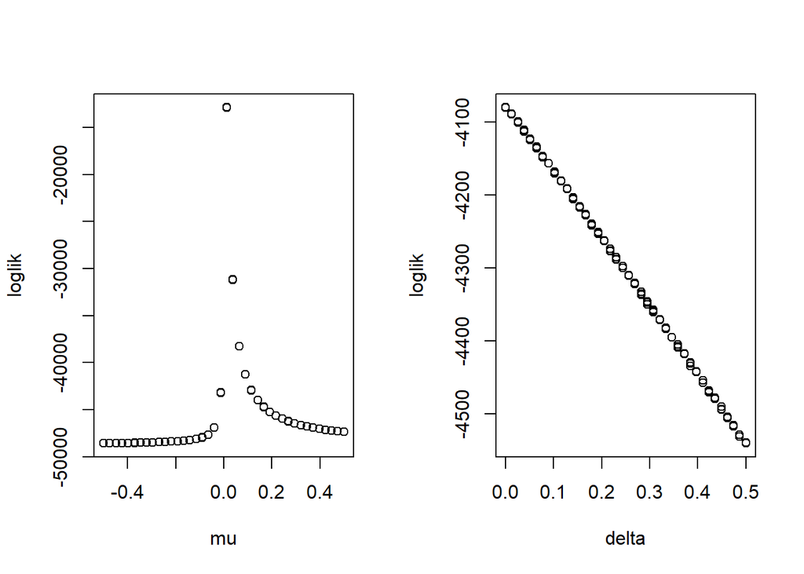

It is obvious that slices offer limited perspective on the geometry of the likelihood surface, there are far more parameter combinations not being tested. With just two parameters $\mu$ and $\delta$, we can evaluate the likelihood at a grid of points and visualize the surface directly.

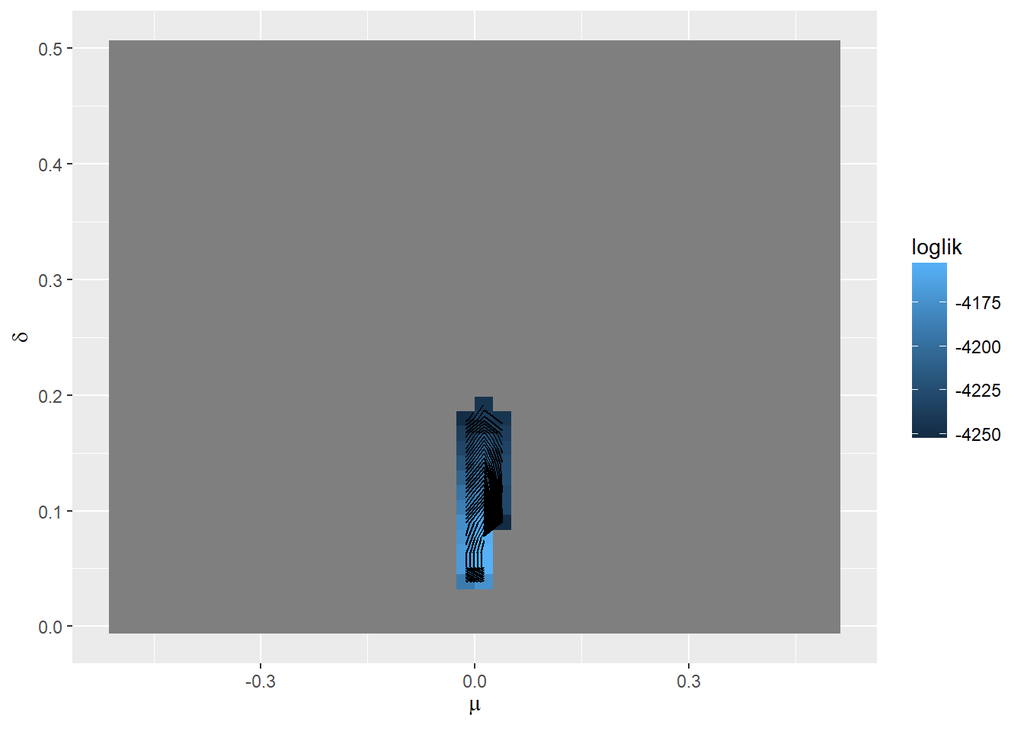

## 4.5 Maximizing the Likelihood Using the Particle Filter

We need to build the new pomp object as follows.

```r
ex2 <<- pomp(
  data=ex_data,
  times="Day",
  t0=0,
  rprocess=euler.sim(step.fun=ex_rprocess,delta.t=1),
  rmeasure=ex_rmeasure,
  dmeasure=ex_dmeasure,
  fromEstimationScale=Csnippet(ex_fromEstimationScale),
  toEstimationScale=Csnippet(ex_toEstimationScale),
  obsnames ="Rate",
  statenames=ex_statenames,
  paramnames=ex_paramnames,
  initializer=Csnippet(ex_initializer))
```

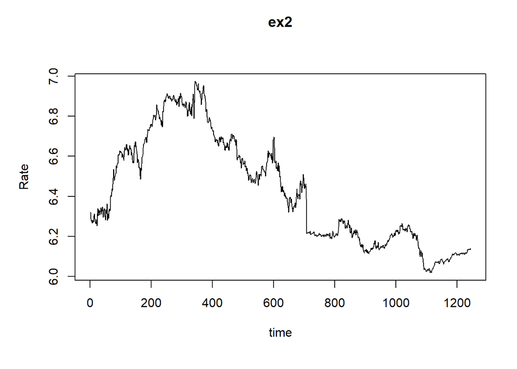

The local maximum search gives us a maximum of likelihood with a standard error.

```
##                      se
## -6548.76900    35.27813
```

## 4.6 A Local Search of the Likelihood Surface

Let’s carry out a local search using mif2 around this previously identified MLE. We set the rw.sd=0.002 and cooling.fraction.50=0.5 algorithmic parameters. We evaluate the likelihood, together with a standard error, using replicated particle filters at each point estimate.

```
##    Min. 1st Qu.  Median    Mean 3rd Qu.    Max.
##   -6544   -6536   -6521   -6497   -6478   -6406
```

These repeated stochastic maximizations can also show us the geometry of the likelihood surface in a neighborhood of this point estimate

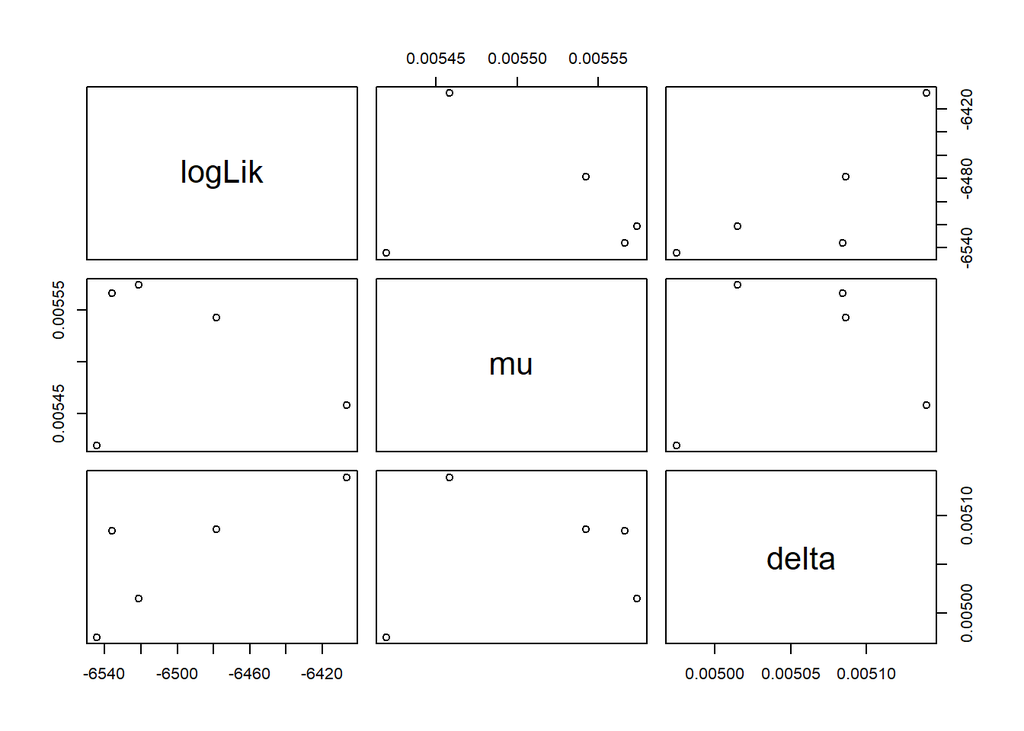

Till now we see the maximum log likelihood is -6406, which is far smaller than that of ARIMA(4,1,4), 3442.17. Therefore, POMP model is not as good as ARIMA model in terms of modeling USD CNH exchange rate.

# 5. Conclusion

We decided to use ARIMA(4,1,4) to model CNH USD exchange rate. As we discrussed, it captured most important information of data set compared with GARCH model and POMP model. As a time series, CNH USD itself is a decent predictor if ARIMA(4,1,4) is as prediction model.

We can add other predicting factors to our analysis, or extend time window to include more data points, or conduct nonlinear variable transformation if we plan to further imporve our analysis.

# 6. Appendix

## 6.1 Explaination

The data analysis report is very intuitive and easy to follow. We first conducted data overview for CNH and USD exchange rate. Then we evaluate our original proposed model ARIMA(4,1,4), and estimate two other non linear models, GARCH(1,1) and POMP. By comparing log likelihood value, we concluded that ARIMA(4,1,4) has the best performance.

## 6.2 Source

[1] Edward L. Ionides, STATS 531 Class notes 4,5,6,7,8.9,10,11,12

[2] Ross, Sheldon M. (2014). “Variations on Brownian Motion”. Introduction to Probability Models (11th ed.). Amsterdam: Elsevier. pp. 612-14.

[3] S&P 500 Index, https://finance.yahoo.com/quote/%5EGSPC/history?p=%5EGSPC

[4] R.H.Shmway and D.S.Stoffer,Time Series Analysis and Its Application, Chapter 4